# Risk Factor Analysis

## Outcome Variable

**Outcome Variable:** y_rate_haz

## Predictor Variables

**Intervention Variable:** impsan

**Adjustment Set:**

- arm
- sex
- W_mage
- meducyrs
- feducyrs
- hhwealth_quart
- hfoodsec
- W_mhtcm
- W_nrooms
- W_nchldlt5
- W_parity
- impfloor
- safeh20
- delta_W_mage
- delta_meducyrs
- delta_feducyrs
- delta_hhwealth_quart
- delta_hfoodsec
- delta_W_mhtcm
- delta_W_nrooms
- delta_W_nchldlt5
- delta_W_parity
- delta_impfloor
- delta_safeh20

## Stratifying Variables

The analysis was stratified on these variable(s):

- agecat
- studyid
- country

## Data Summary

| agecat | studyid | country | impsan | n_cell | n |
| --- | --- | --- | --- | --- | --- |
| 0-3 months | ki0047075b-MAL-ED | BANGLADESH | 0 | 38 | 237 |
| 0-3 months | ki0047075b-MAL-ED | BANGLADESH | 1 | 199 | 237 |
| 0-3 months | ki0047075b-MAL-ED | BRAZIL | 0 | 4 | 174 |
| 0-3 months | ki0047075b-MAL-ED | BRAZIL | 1 | 170 | 174 |
| 0-3 months | ki0047075b-MAL-ED | INDIA | 0 | 101 | 193 |
| 0-3 months | ki0047075b-MAL-ED | INDIA | 1 | 92 | 193 |
| 0-3 months | ki0047075b-MAL-ED | NEPAL | 0 | 1 | 174 |
| 0-3 months | ki0047075b-MAL-ED | NEPAL | 1 | 173 | 174 |
| 0-3 months | ki0047075b-MAL-ED | PERU | 0 | 190 | 252 |
| 0-3 months | ki0047075b-MAL-ED | PERU | 1 | 62 | 252 |
| 0-3 months | ki0047075b-MAL-ED | SOUTH AFRICA | 0 | 209 | 211 |
| 0-3 months | ki0047075b-MAL-ED | SOUTH AFRICA | 1 | 2 | 211 |
| 0-3 months | ki0047075b-MAL-ED | TANZANIA, UNITED REPUBLIC OF | 0 | 217 | 217 |
| 0-3 months | ki0047075b-MAL-ED | TANZANIA, UNITED REPUBLIC OF | 1 | 0 | 217 |
| 0-3 months | ki1017093-NIH-Birth | BANGLADESH | 0 | 348 | 566 |
| 0-3 months | ki1017093-NIH-Birth | BANGLADESH | 1 | 218 | 566 |
| 0-3 months | ki1017093b-PROVIDE | BANGLADESH | 0 | 29 | 634 |
| 0-3 months | ki1017093b-PROVIDE | BANGLADESH | 1 | 605 | 634 |
| 0-3 months | ki1017093c-NIH-Crypto | BANGLADESH | 0 | 84 | 709 |
| 0-3 months | ki1017093c-NIH-Crypto | BANGLADESH | 1 | 625 | 709 |
| 0-3 months | ki1114097-CONTENT | PERU | 0 | 4 | 29 |
| 0-3 months | ki1114097-CONTENT | PERU | 1 | 25 | 29 |
| 0-3 months | ki1135781-COHORTS | GUATEMALA | 0 | 403 | 445 |
| 0-3 months | ki1135781-COHORTS | GUATEMALA | 1 | 42 | 445 |
| 0-3 months | ki1135781-COHORTS | INDIA | 0 | 2928 | 4660 |
| 0-3 months | ki1135781-COHORTS | INDIA | 1 | 1732 | 4660 |
| 0-3 months | kiGH5241-JiVitA-3 | BANGLADESH | 0 | 12644 | 40056 |
| 0-3 months | kiGH5241-JiVitA-3 | BANGLADESH | 1 | 27412 | 40056 |
| 0-3 months | kiGH5241-JiVitA-4 | BANGLADESH | 0 | 814 | 3610 |
| 0-3 months | kiGH5241-JiVitA-4 | BANGLADESH | 1 | 2796 | 3610 |

[output cut: 98 more lines]

The following strata were considered:

- agecat: 0-3 months, studyid: ki0047075b-MAL-ED, country: BANGLADESH
- agecat: 0-3 months, studyid: ki0047075b-MAL-ED, country: BRAZIL
- agecat: 0-3 months, studyid: ki0047075b-MAL-ED, country: INDIA
- agecat: 0-3 months, studyid: ki0047075b-MAL-ED, country: NEPAL
- agecat: 0-3 months, studyid: ki0047075b-MAL-ED, country: PERU
- agecat: 0-3 months, studyid: ki0047075b-MAL-ED, country: SOUTH AFRICA
- agecat: 0-3 months, studyid: ki0047075b-MAL-ED, country: TANZANIA, UNITED REPUBLIC OF
- agecat: 0-3 months, studyid: ki1017093-NIH-Birth, country: BANGLADESH
- agecat: 0-3 months, studyid: ki1017093b-PROVIDE, country: BANGLADESH
- agecat: 0-3 months, studyid: ki1017093c-NIH-Crypto, country: BANGLADESH
- agecat: 0-3 months, studyid: ki1114097-CONTENT, country: PERU
- agecat: 0-3 months, studyid: ki1135781-COHORTS, country: GUATEMALA
- agecat: 0-3 months, studyid: ki1135781-COHORTS, country: INDIA
- agecat: 0-3 months, studyid: kiGH5241-JiVitA-3, country: BANGLADESH
- agecat: 0-3 months, studyid: kiGH5241-JiVitA-4, country: BANGLADESH
- agecat: 12-24 months, studyid: ki0047075b-MAL-ED, country: BANGLADESH
- agecat: 12-24 months, studyid: ki0047075b-MAL-ED, country: BRAZIL
- agecat: 12-24 months, studyid: ki0047075b-MAL-ED, country: INDIA
- agecat: 12-24 months, studyid: ki0047075b-MAL-ED, country: NEPAL
- agecat: 12-24 months, studyid: ki0047075b-MAL-ED, country: PERU
- agecat: 12-24 months, studyid: ki0047075b-MAL-ED, country: SOUTH AFRICA
- agecat: 12-24 months, studyid: ki0047075b-MAL-ED, country: TANZANIA, UNITED REPUBLIC OF
- agecat: 12-24 months, studyid: ki1017093-NIH-Birth, country: BANGLADESH
- agecat: 12-24 months, studyid: ki1017093b-PROVIDE, country: BANGLADESH
- agecat: 12-24 months, studyid: ki1017093c-NIH-Crypto, country: BANGLADESH
- agecat: 12-24 months, studyid: ki1114097-CONTENT, country: PERU
- agecat: 12-24 months, studyid: ki1135781-COHORTS, country: GUATEMALA
- agecat: 12-24 months, studyid: ki1135781-COHORTS, country: INDIA
- agecat: 12-24 months, studyid: ki1135781-COHORTS, country: PHILIPPINES
- agecat: 12-24 months, studyid: ki1148112-LCNI-5, country: MALAWI
- agecat: 12-24 months, studyid: kiGH5241-JiVitA-3, country: BANGLADESH
- agecat: 12-24 months, studyid: kiGH5241-JiVitA-4, country: BANGLADESH
- agecat: 3-6 months, studyid: ki0047075b-MAL-ED, country: BANGLADESH
- agecat: 3-6 months, studyid: ki0047075b-MAL-ED, country: BRAZIL
- agecat: 3-6 months, studyid: ki0047075b-MAL-ED, country: INDIA
- agecat: 3-6 months, studyid: ki0047075b-MAL-ED, country: NEPAL
- agecat: 3-6 months, studyid: ki0047075b-MAL-ED, country: PERU
- agecat: 3-6 months, studyid: ki0047075b-MAL-ED, country: SOUTH AFRICA
- agecat: 3-6 months, studyid: ki0047075b-MAL-ED, country: TANZANIA, UNITED REPUBLIC OF
- agecat: 3-6 months, studyid: ki1017093-NIH-Birth, country: BANGLADESH
- agecat: 3-6 months, studyid: ki1017093b-PROVIDE, country: BANGLADESH
- agecat: 3-6 months, studyid: ki1017093c-NIH-Crypto, country: BANGLADESH
- agecat: 3-6 months, studyid: ki1114097-CONTENT, country: PERU
- agecat: 3-6 months, studyid: ki1135781-COHORTS, country: GUATEMALA
- agecat: 3-6 months, studyid: ki1135781-COHORTS, country: INDIA
- agecat: 3-6 months, studyid: kiGH5241-JiVitA-3, country: BANGLADESH
- agecat: 3-6 months, studyid: kiGH5241-JiVitA-4, country: BANGLADESH
- agecat: 6-12 months, studyid: ki0047075b-MAL-ED, country: BANGLADESH
- agecat: 6-12 months, studyid: ki0047075b-MAL-ED, country: BRAZIL
- agecat: 6-12 months, studyid: ki0047075b-MAL-ED, country: INDIA
- agecat: 6-12 months, studyid: ki0047075b-MAL-ED, country: NEPAL
- agecat: 6-12 months, studyid: ki0047075b-MAL-ED, country: PERU
- agecat: 6-12 months, studyid: ki0047075b-MAL-ED, country: SOUTH AFRICA
- agecat: 6-12 months, studyid: ki0047075b-MAL-ED, country: TANZANIA, UNITED REPUBLIC OF
- agecat: 6-12 months, studyid: ki1017093-NIH-Birth, country: BANGLADESH
- agecat: 6-12 months, studyid: ki1017093b-PROVIDE, country: BANGLADESH
- agecat: 6-12 months, studyid: ki1017093c-NIH-Crypto, country: BANGLADESH
- agecat: 6-12 months, studyid: ki1114097-CONTENT, country: PERU
- agecat: 6-12 months, studyid: ki1135781-COHORTS, country: GUATEMALA
- agecat: 6-12 months, studyid: ki1135781-COHORTS, country: INDIA
- agecat: 6-12 months, studyid: ki1135781-COHORTS, country: PHILIPPINES
- agecat: 6-12 months, studyid: ki1148112-LCNI-5, country: MALAWI
- agecat: 6-12 months, studyid: kiGH5241-JiVitA-3, country: BANGLADESH
- agecat: 6-12 months, studyid: kiGH5241-JiVitA-4, country: BANGLADESH

### Dropped Strata

Some strata were dropped due to rare outcomes:

- agecat: 0-3 months, studyid: ki0047075b-MAL-ED, country: BRAZIL
- agecat: 0-3 months, studyid: ki0047075b-MAL-ED, country: NEPAL
- agecat: 0-3 months, studyid: ki0047075b-MAL-ED, country: SOUTH AFRICA
- agecat: 0-3 months, studyid: ki0047075b-MAL-ED, country: TANZANIA, UNITED REPUBLIC OF
- agecat: 0-3 months, studyid: ki1114097-CONTENT, country: PERU
- agecat: 3-6 months, studyid: ki0047075b-MAL-ED, country: BRAZIL
- agecat: 3-6 months, studyid: ki0047075b-MAL-ED, country: NEPAL
- agecat: 3-6 months, studyid: ki0047075b-MAL-ED, country: SOUTH AFRICA
- agecat: 3-6 months, studyid: ki0047075b-MAL-ED, country: TANZANIA, UNITED REPUBLIC OF
- agecat: 6-12 months, studyid: ki0047075b-MAL-ED, country: BRAZIL
- agecat: 6-12 months, studyid: ki0047075b-MAL-ED, country: NEPAL
- agecat: 6-12 months, studyid: ki0047075b-MAL-ED, country: SOUTH AFRICA
- agecat: 6-12 months, studyid: ki0047075b-MAL-ED, country: TANZANIA, UNITED REPUBLIC OF
- agecat: 6-12 months, studyid: ki1148112-LCNI-5, country: MALAWI
- agecat: 12-24 months, studyid: ki0047075b-MAL-ED, country: BRAZIL
- agecat: 12-24 months, studyid: ki0047075b-MAL-ED, country: NEPAL
- agecat: 12-24 months, studyid: ki0047075b-MAL-ED, country: SOUTH AFRICA
- agecat: 12-24 months, studyid: ki0047075b-MAL-ED, country: TANZANIA, UNITED REPUBLIC OF
- agecat: 12-24 months, studyid: ki1114097-CONTENT, country: PERU
- agecat: 12-24 months, studyid: ki1148112-LCNI-5, country: MALAWI

## Methods Detail

We’re interested in the causal parameters $E[Y_a]$ for all values of $a \in \mathcal{A}$. These parameters represent the mean outcome if, possibly contrary to fact, we intervened to set all units to have $A=a$. Under the randomization and positivity assumptions, these are identified by the statistical parameters $\psi_a=E_W[E_{Y|A,W}(Y|A=a,W)]$. In addition, we’re interested in the mean of $Y$, $E[Y]$ under no intervention (the observed mean). We will estimate these parameters by using SuperLearner to fit the relevant likelihood factors – $E_{Y|A,W}(Y|A=a,W)$ and $p(A=a|W)$, and then updating our likelihood fit using a joint TMLE.

For unadjusted analyses ($W=\{\}$), initial likelihoods were estimated using Lrnr_glm to estimate the simple $E(Y|A)$ and Lrnr_mean to estimate $p(A)$. For adjusted analyses, a small library containing Lrnr_glmnet, Lrnr_xgboost, and Lrnr_mean was used.

Having estimated these parameters, we will then use the delta method to estimate relative risks and attributable risks relative to a prespecified baseline level of $A$.

# Results Detail

## Results Plots

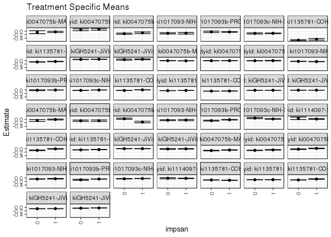

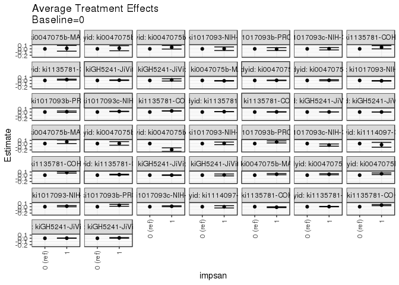

## Results Table

### Parameter: TSM

| agecat | studyid | country | intervention_level | baseline_level | estimate | ci_lower | ci_upper |
| --- | --- | --- | --- | --- | --- | --- | --- |
| 0-3 months | ki0047075b-MAL-ED | BANGLADESH | 0 | NA | -0.0565943 | -0.1406604 | 0.0274718 |
| 0-3 months | ki0047075b-MAL-ED | BANGLADESH | 1 | NA | -0.0379350 | -0.0715997 | -0.0042704 |
| 0-3 months | ki0047075b-MAL-ED | INDIA | 0 | NA | 0.0874312 | 0.0340103 | 0.1408521 |
| 0-3 months | ki0047075b-MAL-ED | INDIA | 1 | NA | 0.1080116 | 0.0556915 | 0.1603316 |
| 0-3 months | ki0047075b-MAL-ED | PERU | 0 | NA | -0.1402001 | -0.1741633 | -0.1062369 |
| 0-3 months | ki0047075b-MAL-ED | PERU | 1 | NA | -0.0885545 | -0.1342321 | -0.0428769 |
| 0-3 months | ki1017093-NIH-Birth | BANGLADESH | 0 | NA | -0.1208348 | -0.1537006 | -0.0879690 |
| 0-3 months | ki1017093-NIH-Birth | BANGLADESH | 1 | NA | -0.1163746 | -0.1622922 | -0.0704570 |
| 0-3 months | ki1017093b-PROVIDE | BANGLADESH | 0 | NA | -0.0344027 | -0.0749564 | 0.0061509 |
| 0-3 months | ki1017093b-PROVIDE | BANGLADESH | 1 | NA | -0.0407532 | -0.0594079 | -0.0220984 |
| 0-3 months | ki1017093c-NIH-Crypto | BANGLADESH | 0 | NA | -0.1239712 | -0.1557464 | -0.0921959 |
| 0-3 months | ki1017093c-NIH-Crypto | BANGLADESH | 1 | NA | -0.1196638 | -0.1393892 | -0.0999384 |
| 0-3 months | ki1135781-COHORTS | GUATEMALA | 0 | NA | -0.5158008 | -0.5444848 | -0.4871169 |
| 0-3 months | ki1135781-COHORTS | GUATEMALA | 1 | NA | -0.4639148 | -0.5099171 | -0.4179124 |
| 0-3 months | ki1135781-COHORTS | INDIA | 0 | NA | -0.0782581 | -0.0883143 | -0.0682019 |
| 0-3 months | ki1135781-COHORTS | INDIA | 1 | NA | -0.0535213 | -0.0661007 | -0.0409418 |
| 0-3 months | kiGH5241-JiVitA-3 | BANGLADESH | 0 | NA | 0.0662645 | 0.0582998 | 0.0742292 |
| 0-3 months | kiGH5241-JiVitA-3 | BANGLADESH | 1 | NA | 0.0744062 | 0.0689507 | 0.0798617 |
| 0-3 months | kiGH5241-JiVitA-4 | BANGLADESH | 0 | NA | 0.0566353 | 0.0259016 | 0.0873690 |
| 0-3 months | kiGH5241-JiVitA-4 | BANGLADESH | 1 | NA | 0.0738996 | 0.0569978 | 0.0908014 |
| 3-6 months | ki0047075b-MAL-ED | BANGLADESH | 0 | NA | -0.0700737 | -0.1202154 | -0.0199321 |
| 3-6 months | ki0047075b-MAL-ED | BANGLADESH | 1 | NA | -0.0132258 | -0.0385902 | 0.0121386 |
| 3-6 months | ki0047075b-MAL-ED | INDIA | 0 | NA | -0.0849392 | -0.1223190 | -0.0475595 |
| 3-6 months | ki0047075b-MAL-ED | INDIA | 1 | NA | -0.0798342 | -0.1201871 | -0.0394813 |
| 3-6 months | ki0047075b-MAL-ED | PERU | 0 | NA | 0.0311713 | -0.0026781 | 0.0650206 |
| 3-6 months | ki0047075b-MAL-ED | PERU | 1 | NA | -0.1576625 | -0.2027690 | -0.1125559 |
| 3-6 months | ki1017093-NIH-Birth | BANGLADESH | 0 | NA | -0.0530637 | -0.0786356 | -0.0274918 |
| 3-6 months | ki1017093-NIH-Birth | BANGLADESH | 1 | NA | -0.0462085 | -0.0800784 | -0.0123386 |
| 3-6 months | ki1017093b-PROVIDE | BANGLADESH | 0 | NA | -0.0779650 | -0.1038796 | -0.0520503 |
| 3-6 months | ki1017093b-PROVIDE | BANGLADESH | 1 | NA | -0.0260994 | -0.0431450 | -0.0090539 |

[output cut: 58 more lines]

### Parameter: E(Y)

[output not shown]

### Parameter: ATE

| agecat | studyid | country | intervention_level | baseline_level | estimate | ci_lower | ci_upper |
| --- | --- | --- | --- | --- | --- | --- | --- |
| 0-3 months | ki0047075b-MAL-ED | BANGLADESH | 0 | 0 | 0.0000000 | 0.0000000 | 0.0000000 |
| 0-3 months | ki0047075b-MAL-ED | BANGLADESH | 1 | 0 | 0.0186593 | -0.0717515 | 0.1090701 |
| 0-3 months | ki0047075b-MAL-ED | INDIA | 0 | 0 | 0.0000000 | 0.0000000 | 0.0000000 |
| 0-3 months | ki0047075b-MAL-ED | INDIA | 1 | 0 | 0.0205804 | -0.0587398 | 0.0999006 |
| 0-3 months | ki0047075b-MAL-ED | PERU | 0 | 0 | 0.0000000 | 0.0000000 | 0.0000000 |
| 0-3 months | ki0047075b-MAL-ED | PERU | 1 | 0 | 0.0516456 | -0.0050225 | 0.1083137 |
| 0-3 months | ki1017093-NIH-Birth | BANGLADESH | 0 | 0 | 0.0000000 | 0.0000000 | 0.0000000 |
| 0-3 months | ki1017093-NIH-Birth | BANGLADESH | 1 | 0 | 0.0044602 | -0.0518127 | 0.0607331 |
| 0-3 months | ki1017093b-PROVIDE | BANGLADESH | 0 | 0 | 0.0000000 | 0.0000000 | 0.0000000 |
| 0-3 months | ki1017093b-PROVIDE | BANGLADESH | 1 | 0 | -0.0063505 | -0.0506788 | 0.0379778 |
| 0-3 months | ki1017093c-NIH-Crypto | BANGLADESH | 0 | 0 | 0.0000000 | 0.0000000 | 0.0000000 |
| 0-3 months | ki1017093c-NIH-Crypto | BANGLADESH | 1 | 0 | 0.0043074 | -0.0330912 | 0.0417060 |
| 0-3 months | ki1135781-COHORTS | GUATEMALA | 0 | 0 | 0.0000000 | 0.0000000 | 0.0000000 |
| 0-3 months | ki1135781-COHORTS | GUATEMALA | 1 | 0 | 0.0518860 | -0.0003142 | 0.1040863 |
| 0-3 months | ki1135781-COHORTS | INDIA | 0 | 0 | 0.0000000 | 0.0000000 | 0.0000000 |
| 0-3 months | ki1135781-COHORTS | INDIA | 1 | 0 | 0.0247368 | 0.0088612 | 0.0406124 |
| 0-3 months | kiGH5241-JiVitA-3 | BANGLADESH | 0 | 0 | 0.0000000 | 0.0000000 | 0.0000000 |
| 0-3 months | kiGH5241-JiVitA-3 | BANGLADESH | 1 | 0 | 0.0081417 | -0.0005757 | 0.0168591 |
| 0-3 months | kiGH5241-JiVitA-4 | BANGLADESH | 0 | 0 | 0.0000000 | 0.0000000 | 0.0000000 |
| 0-3 months | kiGH5241-JiVitA-4 | BANGLADESH | 1 | 0 | 0.0172643 | -0.0180348 | 0.0525634 |
| 3-6 months | ki0047075b-MAL-ED | BANGLADESH | 0 | 0 | 0.0000000 | 0.0000000 | 0.0000000 |
| 3-6 months | ki0047075b-MAL-ED | BANGLADESH | 1 | 0 | 0.0568479 | 0.0010541 | 0.1126418 |
| 3-6 months | ki0047075b-MAL-ED | INDIA | 0 | 0 | 0.0000000 | 0.0000000 | 0.0000000 |
| 3-6 months | ki0047075b-MAL-ED | INDIA | 1 | 0 | 0.0051050 | -0.0504879 | 0.0606980 |
| 3-6 months | ki0047075b-MAL-ED | PERU | 0 | 0 | 0.0000000 | 0.0000000 | 0.0000000 |
| 3-6 months | ki0047075b-MAL-ED | PERU | 1 | 0 | -0.1888337 | -0.2452416 | -0.1324259 |
| 3-6 months | ki1017093-NIH-Birth | BANGLADESH | 0 | 0 | 0.0000000 | 0.0000000 | 0.0000000 |
| 3-6 months | ki1017093-NIH-Birth | BANGLADESH | 1 | 0 | 0.0068552 | -0.0333112 | 0.0470216 |
| 3-6 months | ki1017093b-PROVIDE | BANGLADESH | 0 | 0 | 0.0000000 | 0.0000000 | 0.0000000 |
| 3-6 months | ki1017093b-PROVIDE | BANGLADESH | 1 | 0 | 0.0518656 | 0.0208773 | 0.0828538 |

[output cut: 58 more lines]